# Classification Non Supervisée

```r
data=read.csv("../Data/socsupport.csv",header=TRUE,sep=";")
attach(data)
str(data)
```

```
## 'data.frame':    95 obs. of  21 variables:
##  $ X           : int  1 2 3 4 5 6 7 8 9 10 ...
##  $ gender      : Factor w/ 2 levels "female","male": 2 1 2 2 1 1 1 1 1 2 ...
##  $ age         : Factor w/ 5 levels "18-20","21-24",..: 2 2 2 1 2 2 3 3 1 5 ...
##  $ country     : Factor w/ 2 levels "australia","other": 1 1 1 1 1 1 1 1 1 1 ...
##  $ marital     : Factor w/ 3 levels "married","other",..: 2 3 3 3 3 3 1 1 3 2 ...
##  $ livewith    : Factor w/ 6 levels "alone","friends",..: 5 5 6 4 2 2 5 5 4 1 ...
##  $ employment  : Factor w/ 5 levels "employed fulltime",..: 2 5 2 2 2 3 2 2 2 2 ...
##  $ firstyr     : Factor w/ 2 levels "first year","other": 2 2 2 1 2 2 2 2 2 2 ...
##  $ enrolment   : Factor w/ 3 levels "","full-time",..: 2 2 2 2 2 2 2 3 2 2 ...
##  $ emotional   : int  22 21 21 19 16 20 20 20 24 13 ...
##  $ emotionalsat: int  23 20 18 19 19 17 23 20 25 18 ...
##  $ tangible    : int  17 12 16 20 11 16 20 16 20 6 ...
##  $ tangiblesat : int  18 10 16 17 15 15 20 16 20 14 ...
##  $ affect      : int  15 10 15 11 6 12 14 12 15 6 ...
##  $ affectsat   : int  15 6 15 11 10 14 15 12 15 12 ...
##  $ psi         : int  12 9 13 13 11 12 15 12 12 6 ...
##  $ psisat      : int  13 6 12 12 12 11 15 12 15 11 ...
##  $ esupport    : int  13 12 14 15 9 13 15 13 16 10 ...
##  $ psupport    : int  11 7 13 15 7 12 10 11 NA 8 ...
##  $ supsources  : int  13 10 14 15 9 13 13 11 NA 9 ...
##  $ BDI         : int  5 8 16 0 9 0 1 14 12 20 ...
```

Dans un premier temps, nous allons étudier l’ensemble du jeu de données à l’aide de la fonction FAMD car cette fonction est applicable à la fois sur les variables quantitatives et qualitatives. Comme nous avons pu le faire pour l’ACP, nous devons supprimer les individus dont certaines données sont non acquises.

```r
library("FactoMineR")
data = data[,-c(1)]
n=nrow(data)
p=ncol(data)

delete = vector("numeric",n)

for(i in 1:n){
  for(j in 1:p){
    if(is.na(data[i,j]))
      delete[i]=1
  }
}

for(i in n:1){
  if (delete[i]==1)
    data=data[-c(i),]
}

nonsuper = FAMD(data)
```

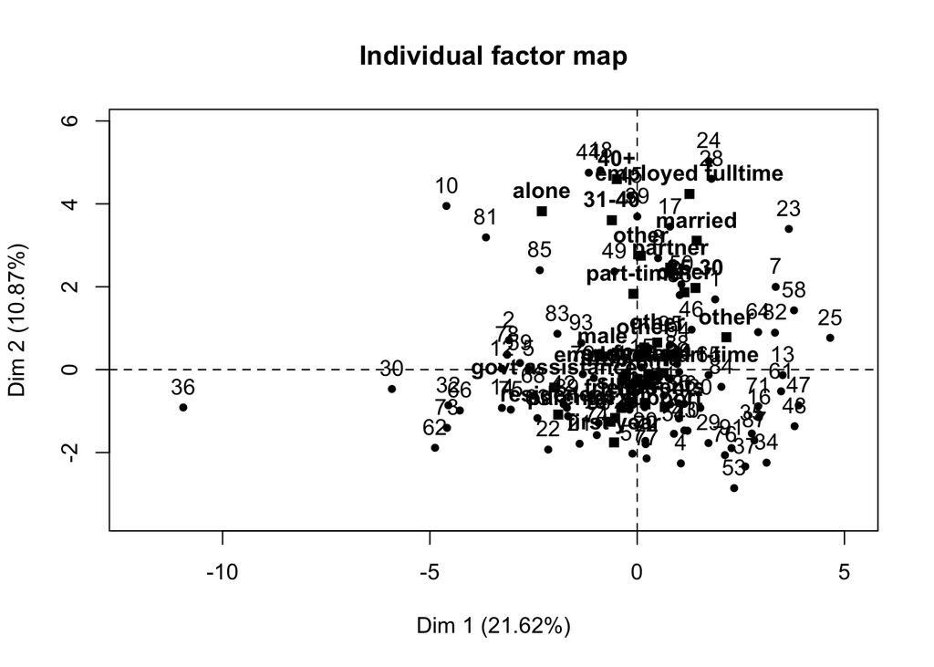

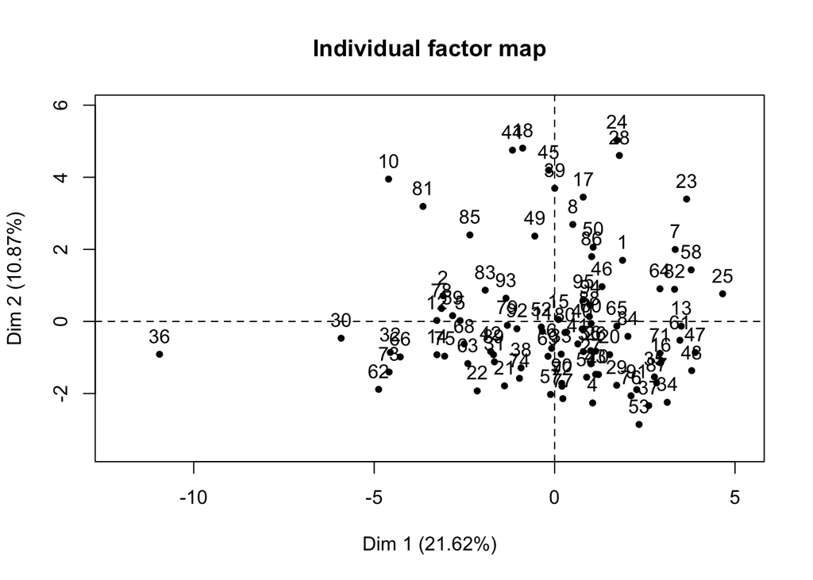

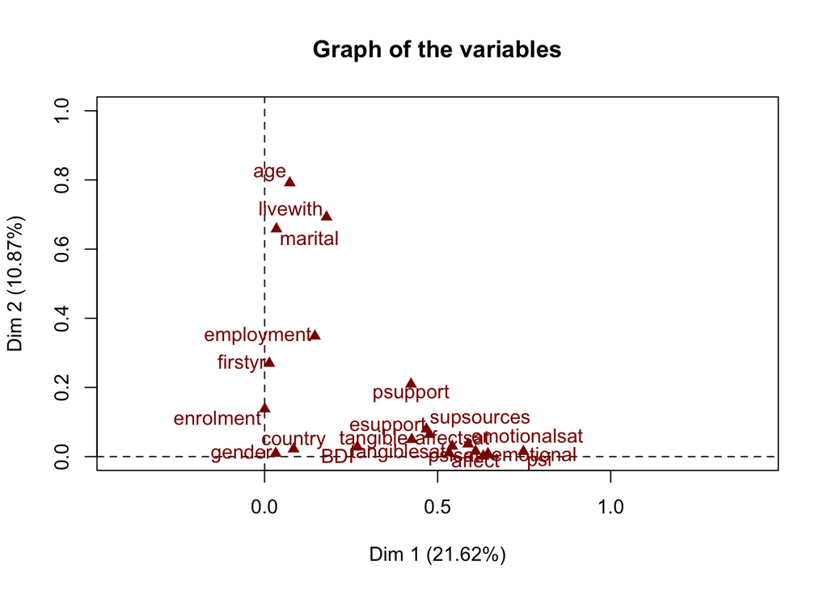

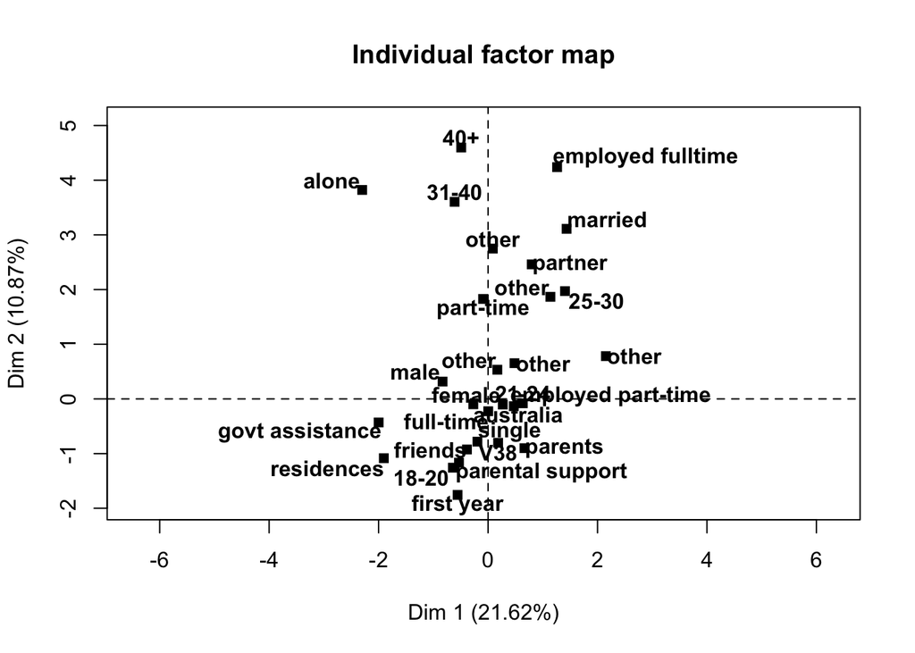

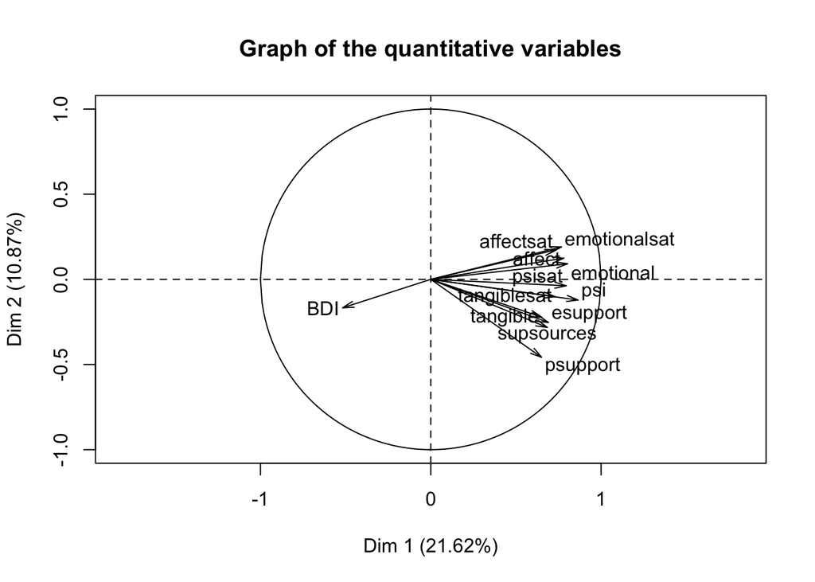

```r
nonsuper
```

```
## *The results are available in the following objects:
##
##   name          description
## 1 "$eig"        "eigenvalues and inertia"
## 2 "$var"        "Results for the variables"
## 3 "$ind"        "results for the individuals"
## 4 "$quali.var"  "Results for the qualitative variables"
## 5 "$quanti.var" "Results for the quantitative variables"
```

```r
summary(nonsuper,nbelements = Inf)
```

```
##
## Call:
## FAMD(base = data)
##
##
## Eigenvalues
##                       Dim.1  Dim.2  Dim.3  Dim.4  Dim.5
## Variance              6.919  3.477  1.968  1.831  1.604
## % of var.            21.623 10.867  6.149  5.720  5.011
## Cumulative % of var. 21.623 32.489 38.638 44.359 49.370
##
## Individuals
##                         Dist     Dim.1     ctr    cos2     Dim.2     ctr
## 1                  |   4.737 |   1.882   0.569   0.158 |   1.696   0.919
## 2                  |   5.722 |  -3.094   1.537   0.292 |   0.713   0.162
## 3                  |   3.999 |   0.795   0.102   0.040 |  -0.837   0.224
## 4                  |   4.392 |   1.054   0.178   0.058 |  -2.262   1.635
## 5                  |   5.315 |  -2.620   1.102   0.243 |   0.024   0.000
## 6                  |   4.932 |  -0.083   0.001   0.000 |  -0.748   0.179
## 7                  |   6.186 |   3.341   1.793   0.292 |   1.997   1.274
## 8                  |   5.970 |   0.504   0.041   0.007 |   2.690   2.313
## 10                 |  10.200 |  -4.601   3.400   0.204 |   3.949   4.983
## 11                 |   3.363 |  -0.339   0.019   0.010 |  -0.276   0.024
## 12                 |   5.435 |  -3.265   1.712   0.361 |   0.027   0.000
## 13                 |   6.836 |   3.510   1.978   0.264 |  -0.131   0.005
## 14                 |   5.177 |  -3.261   1.708   0.397 |  -0.924   0.273
## 15                 |   3.988 |   0.104   0.002   0.001 |   0.053   0.001
## 16                 |   3.927 |   2.936   1.384   0.559 |  -1.149   0.422
## 17                 |   8.460 |   0.792   0.101   0.009 |   3.449   3.802
## 18                 |   7.609 |  -0.886   0.126   0.014 |   4.808   7.387
## 20                 |   3.546 |   1.524   0.373   0.185 |  -0.922   0.272
## 21                 |   4.321 |  -1.389   0.310   0.103 |  -1.788   1.021
## 22                 |   4.826 |  -2.145   0.739   0.198 |  -1.928   1.188
## 23                 |   7.298 |   3.658   2.149   0.251 |   3.395   3.683
## 24                 |   9.534 |   1.732   0.482   0.033 |   5.029   8.081
## 25                 |   7.137 |   4.656   3.481   0.426 |   0.768   0.188
## 26                 |   4.349 |   1.137   0.208   0.068 |  -0.824   0.217
## 27                 |   2.968 |   1.005   0.162   0.115 |  -1.176   0.442
## 28                 |   7.683 |   1.794   0.517   0.055 |   4.605   6.775
## 29                 |   4.901 |   1.720   0.475   0.123 |  -1.771   1.002
```

[output cut: 227 more lines]

```
## friends            -1.358 | -1.130  2.567  0.094 -2.208 |
## other               0.614 | -0.101  0.009  0.000 -0.126 |
## parents            -3.894 |  0.517  2.911  0.110  2.970 |
## partner             6.868 | -0.582  2.040  0.042 -2.159 |
## residences         -2.837 | -0.263  0.376  0.009 -0.913 |
## employed fulltime   3.233 | -1.880  2.028  0.056 -1.906 |
## employed part-time -0.645 | -0.376  1.744  0.087 -2.419 |
## govt assistance    -0.935 | -1.205  5.830  0.152 -3.477 |
## other               3.881 |  1.646 10.110  0.254  4.549 |
## parental support   -2.950 |  0.855  3.776  0.123  2.875 |
## first year         -4.899 |  0.774  3.608  0.095  2.871 |
## other               4.899 | -0.235  1.098  0.095 -2.871 |
## V38                -0.875 |  2.155  5.333  0.176  3.126 |
## full-time          -2.550 | -0.284  1.734  0.286 -4.269 |
## part-time           3.452 |  1.151  4.186  0.126  2.890 |
```

Sur le graphique des individus on trouve une grande partie des individus au niveau de l’origine avec tout de même quelques variations(des individus légèrement au dessus ou en dessous selon l’axe 2). On observe également quelques individus qui se séparent du groupe horizontalement (axe 1).

Sur le graphique des variables, on semble apercevoir que l’axe 1 est globalement plus influencé par les variables quantitatives et l’axe 2 par les variables qualitatives. Cela est confirmé par le sommaire de nonsuper où l’on voit respectivement une plus grande contribution des variables quantitatives sur l’axe 1 et une plus grande contribution des variables qualitatives sur l’axe 2.

Nous retrouvons à peu près les mêmes graphiques au niveau du cercle des corrélations et des variables qualitatives que lors des étude précédentes.

On ne peut tirer plus de conclusions de ces graphiques qui sont peu lisibles.

L’idée est maintenant d’étudier séparément les variables quantitatives et qualitatives à l’aide respectivement des méthodes CAH et k-means.

Dendogramme pour choisir le nombre de classes sur les variabes quantitatives :

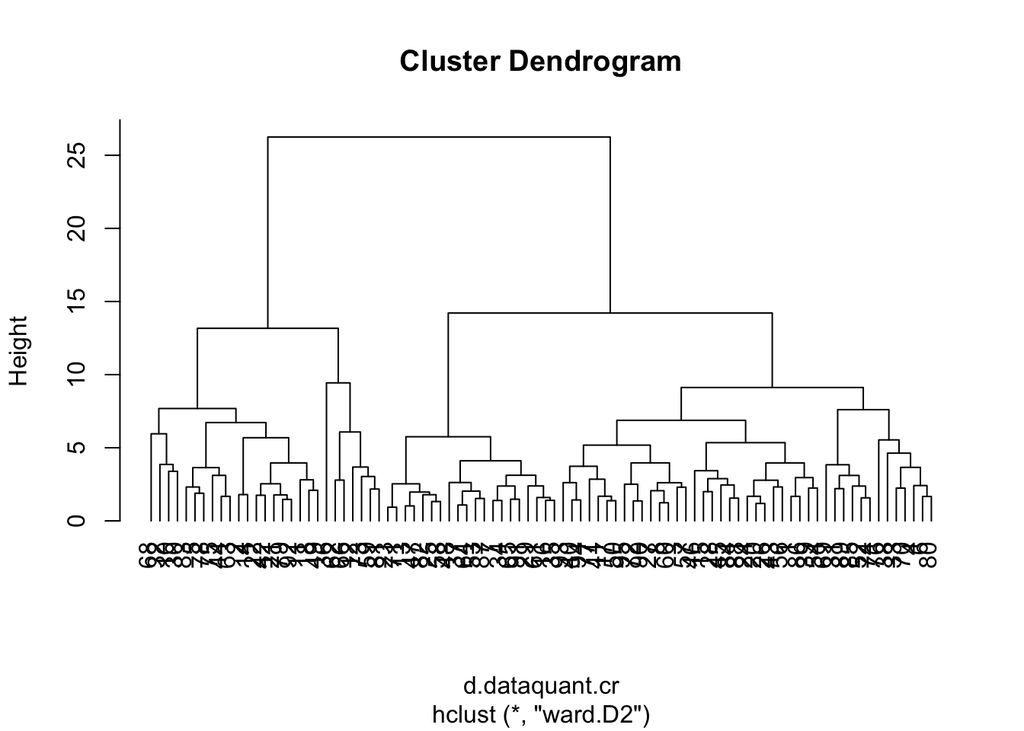

```r
dataquant = data[,-c(1,2,3,4,5,6,7,8)]
dataquant.cr <- scale(dataquant,center=T,scale=T)
d.dataquant.cr <- dist(dataquant.cr)
cah.ward.cr <- hclust(d.dataquant.cr,method="ward.D2")
plot(cah.ward.cr,hang =-1)
```

Le dendogramme ci-dessus nous laisse penser que 4 classes seront suffisantes pour extraire suffisamment d’informations du jeu de données.

On pose donc K=4 et on affiche le même graphique avec les 4 groupes apparents.

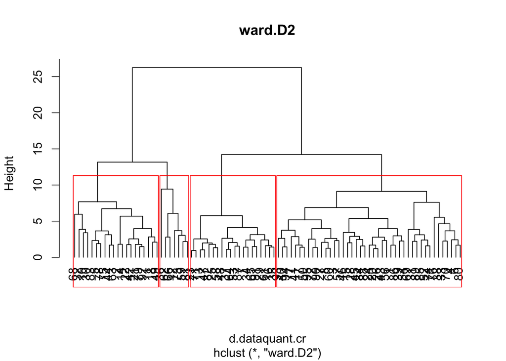

```r
K=4
plot(cah.ward.cr,hang =-1,main="ward.D2")
rect.hclust(cah.ward.cr,k=4)
```

On regroupe maintenant les individus suivant ces 4 groupes et on calcule les moyennes pour chaque variable.

```r
groupes.4 <- cutree(cah.ward.cr,k=4)
table(groupes.4)
```

```
## groupes.4
##  1  2  3  4
## 43 20 20  7
```

```r
K=4
Means_groupes <- matrix(NA, nrow=K, ncol=dim(dataquant)[2])
colnames(Means_groupes)=colnames(dataquant)
for (i in 1:K) Means_groupes[i,]<- colMeans(dataquant[groupes.4==i,])
Means_groupes
```

```
##      emotional emotionalsat tangible tangiblesat    affect affectsat
## [1,]  19.86047     20.04651 17.67442    17.69767 12.906977 12.976744
## [2,]  17.70000     19.05000 11.45000    13.10000  9.200000 10.450000
## [3,]  22.20000     22.45000 19.35000    19.60000 14.400000 14.450000
## [4,]  13.42857     14.42857 15.42857    15.71429  8.571429  8.142857
##            psi    psisat  esupport  psupport supsources       BDI
## [1,] 12.186047 12.418605 12.674419 10.558140  10.767442  9.023256
## [2,] 10.250000 11.300000 11.550000  7.950000   9.750000 11.550000
## [3,] 14.400000 14.550000 15.500000 13.900000  13.500000  7.550000
## [4,]  7.142857  6.714286  9.428571  6.857143   7.428571 29.571429
```

Tout d’abord, on observe que le groupe 1, qui est le groupe le plus représenté, a un indice proche de la moyenne pour toutes les variables quantitatives (voir colonne mean de summary plus bas). On en déduit que ce groupe correspond à la masse d’individu à l’origine sur le graphique des individus. Les groupes 2 et 3 sont respectivement légèrement en dessous et au dessus de la moyenne pour toutes les variables quantitatives excepté pour le score au BDI où ils sont respectivement légèrement au dessus et légèrement en dessous de la moyenne. Finalement, le groupe le moins représenté est le groupe 4 avec seulement 7 individus. Ce groupe montre bien la corrélation entre l’état dépressif et l’état des autres facteurs émotionnels. En effet, leur score au BDI est très largement supérieur à ceux des autres groupes et leur état émotionnel est déplorable ce qui est cohérent avec nos précédentes analyses.

```r
summary(dataquant)
```

```
##    emotional     emotionalsat      tangible      tangiblesat
##  Min.   : 6.0   Min.   : 8.00   Min.   : 4.00   Min.   : 8.00
##  1st Qu.:18.0   1st Qu.:19.00   1st Qu.:14.00   1st Qu.:15.25
##  Median :20.0   Median :20.00   Median :18.00   Median :17.50
##  Mean   :19.4   Mean   :19.92   Mean   :16.49   Mean   :16.94
##  3rd Qu.:21.0   3rd Qu.:22.00   3rd Qu.:20.00   3rd Qu.:20.00
##  Max.   :25.0   Max.   :25.00   Max.   :20.00   Max.   :20.00
##      affect        affectsat          psi            psisat
##  Min.   : 3.00   Min.   : 3.00   Min.   : 5.00   Min.   : 5.00
##  1st Qu.:10.00   1st Qu.:11.00   1st Qu.:11.00   1st Qu.:11.25
##  Median :13.00   Median :13.00   Median :12.00   Median :12.00
##  Mean   :12.08   Mean   :12.37   Mean   :11.86   Mean   :12.20
##  3rd Qu.:15.00   3rd Qu.:15.00   3rd Qu.:14.00   3rd Qu.:14.00
##  Max.   :15.00   Max.   :15.00   Max.   :15.00   Max.   :15.00
##     esupport       psupport       supsources         BDI
##  Min.   : 6.0   Min.   : 4.00   Min.   : 5.00   Min.   : 0.00
##  1st Qu.:11.0   1st Qu.: 8.00   1st Qu.: 9.00   1st Qu.: 5.00
##  Median :13.0   Median :10.00   Median :11.00   Median : 8.50
##  Mean   :12.8   Mean   :10.43   Mean   :10.89   Mean   :10.86
##  3rd Qu.:14.0   3rd Qu.:12.75   3rd Qu.:13.00   3rd Qu.:14.00
##  Max.   :19.0   Max.   :20.00   Max.   :16.00   Max.   :48.00
```

Nous passons à l’étude de la deuxième partie du jeu de données en utilisant le k-means.

On applique l’ACM sur les données qualitatives :

```r
dataqual = data[,-c(9,10,11,12,13,14,15,16,17,18,19,20)]


acm=MCA(dataqual,graph = F)
```

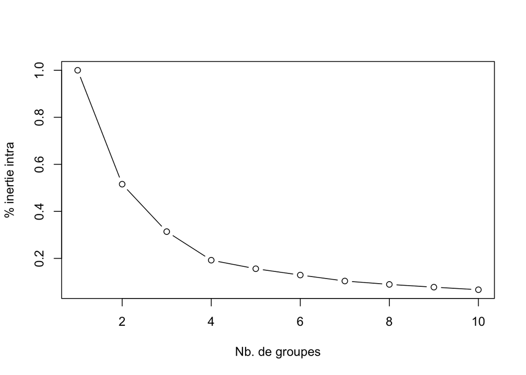

```r
inertie.intra <- rep(0,10)
for (k in 1:10){
kmeans.acm <- kmeans(acm$ind$coord[,1:2],centers=k,nstart=100)
inertie.intra[k] <- kmeans.acm$tot.withinss/kmeans.acm$totss
}

plot(1:10,inertie.intra,type="b",xlab="Nb. de groupes",ylab="% inertie intra")
```

Le graphique nous montre que 4 classes sont suffisantes pour avoir suffisamment d’informations (environ 80%).

Nous allons observer le clustering avec 4 classes.

```r
K=4
kmeans.acm <-  kmeans(acm$ind$coord[,1:2],centers=K,nstart=100)
table(kmeans.acm$cluster)
```

```
##
##  1  2  3  4
##  8 36 14 32
```

```r
kmeans.acm$cluster
```

```
##  1  2  3  4  5  6  7  8 10 11 12 13 14 15 16 17 18 20 21 22 23 24 25 26 27
##  3  2  2  4  2  2  3  3  1  2  2  2  4  2  2  3  1  2  4  4  1  1  3  2  2
## 28 29 30 31 32 33 34 35 36 37 38 39 40 41 42 43 44 45 46 47 48 49 50 52 53
##  1  2  4  4  4  2  4  4  4  4  2  1  2  2  2  4  1  1  4  2  2  3  3  2  4
## 54 56 57 58 59 60 61 62 63 64 65 66 68 69 70 71 72 73 74 75 76 77 78 79 80
##  4  4  4  3  2  2  4  4  4  3  2  2  2  4  2  2  4  4  4  4  4  4  4  4  2
## 81 82 83 84 85 86 87 88 89 90 91 92 93 94 95
##  3  3  2  4  3  3  2  2  2  4  4  2  2  2  3
```

En observant groupes.4 et kmeans$acm.cluster, on se rend compte que les répartitions obtenues à l’aide des deux méthodes ne correspondent pas.

```r
table(kmeans.acm$cluster,dataqual[,1])
```

```
##
##     female male
##   1      4    4
##   2     29    7
##   3     12    2
##   4     23    9
```

En dehors d’un groupe qui est assez homogène, la majorité des groupes est composé majoritairement de femmes mais le nombre de femmes étant largement supérieur au nombre d’hommes, il n’est pas très pertinent de tirer des conclusions à partir de cette information.

```r
table(kmeans.acm$cluster,dataqual[,2])
```

```
##
##     18-20 21-24 25-30 31-40 40+
##   1     0     0     0     4   4
##   2    10    25     1     0   0
##   3     0     7     5     2   0
##   4    29     3     0     0   0
```

On remarque 2 groupes jeunes, un groupe plus agé et un groupe entre les deux.

```r
table(kmeans.acm$cluster,dataqual[,3])
```

```
##
##     australia other
##   1         6     2
##   2        33     3
##   3        11     3
##   4        30     2
```

De même que pour le genre, le nombre d’australiens et “d’étrangers” est trop différent pour pouvoir utiliser cette information. Nous avions déjà remarqué cela lors de l’utilisation de la fonction FAMD et l’analyse descriptive. Nous pourrions éventuellement recommencer l’étude en supprimant ces variables qui n’ont pas grande importance.

```r
table(kmeans.acm$cluster,dataqual[,4])
```

```
##
##     married other single
##   1       4     3      1
##   2       0     0     36
##   3       5     7      2
##   4       0     0     32
```

Nous avons ici 2 groupes d’individus célibataires et 2 groupes avec des individus dans des situations mariées ou autres.

```r
table(kmeans.acm$cluster,dataqual[,5])
```

```
##
##     alone friends other parents partner residences
##   1     2       0     0       0       6          0
##   2     0       6     2      19       3          6
##   3     0       0     1       1      12          0
##   4     0       1     0      18       0         13
```

Ici, nous avons 2 groupes qui vivent plus généralement en résidence, avec leurs amis ou leurs parents. Les 2 autres groupes sont plus amenés à vivre avec un(e) partenaire.

```r
table(kmeans.acm$cluster,dataqual[,6])
```

```
##
##     employed fulltime employed part-time govt assistance other
##   1                 1                  1               0     6
##   2                 0                 25               5     1
##   3                 1                 10               2     1
##   4                 0                  7               7     5
##
##     parental support
##   1                0
##   2                5
##   3                0
##   4               13
```

```r
table(kmeans.acm$cluster,dataqual[,7])
```

```
##
##     first year other
##   1          0     8
##   2          0    36
##   3          0    14
##   4         21    11
```

```r
table(kmeans.acm$cluster,dataqual[,8])
```

```
##
##        full-time part-time
##   1  0         4         4
##   2  0        33         3
##   3  0        13         1
##   4  4        25         3
```

Pour résumé :

Nous voyons que les 4 groupes de chaque étude ne sont pas associables les uns aux autres et donc que nous ne pouvons pas établir de relation entre variables quantitatives et qualitatives à partir de cela. Nous allons maintenant à l’aide d’une méthode de classification supervisée vérifier qu’il n’y ait réellement pas de lien.